# 예측 모델

## 데이터 분할

- K-fold Cross Validation: 전체 데이터를 k개로 분할한 후, 1개의 데이터를 제외한 데이터를 test 데이터로 사용
  - 목적: 최적의 Hyper Parameter 설정을 통한 좋은 모델 설정-> 모델의 안정적인 일반화 성능 확보
- Grid Search: Hyper Parameter 값을 일정 간격으로 조합-> 최적 성능의 모델 탐색
  - 상대적으로 조합수가 적을 때 사용

## 회귀분석

- 정의: 연속형 목표변수(종속, 결과, Target)와 설명변수(독립, 원인, Input) 관계를 함수화-> 목표변수를 분석, 예측하는 통계기법
- 목적: 목표변수에 영향을 미치는 설명변수를 찾고 목표변수의 값 예측
- 장점: 실제성, 친밀성, 해석 및 설명력, 적절한 변수 선택
- 단점: 기본 가정이 요구됨, 비선형성 확인이 어려움, 결측치는 무조건 제외됨

### 선형회귀

#### 단순 선형회귀

- 설명변수 1개, 목표변수와 선형관계를 가지는 회귀 모델
- 분석 절차
  1. 경향성 확인: 변수 간의 상관성 확인
  2. 모델링: 회귀계수 계산
  3. 모델의 적합성 확인: 표준오차, 결정계수, ANOVA 분석결과 확인
  4. 오차(잔차)의 가정 확인: 오차의 정규성, 등분산성, 독립성 확인
  5. 모델 확정

```python
# 데이터 처리
import pandas as pd

# 행렬 연산
import numpy as np

# 데이터 시각화
import matplotlib
import matplotlib.pyplot as plt
import seaborn as sns

# 회귀분석
from statsmodels.formula.api import ols

# qqplot, 회귀분석의 상수항 추가
from statsmodels.api import qqplot, add_constant

# 선형 모델 formula(y ~ X1 + X2 + ...)
import statsmodels.formula.api as smf

# 평가함수
from statsmodels.tools.eval_measures import rmse
```

```python
matplotlib.rc('font', family='NanumGothic')
matplotlib.rcParams['axes.unicode_minus'] = False
plt.rcParams["font.family"] = 'NanumGothic'
```

```python
df_raw = pd.read_csv("../빅데이터 기초/Data/부품수리시간.csv")
df_raw.head()
```

|  | UNITS | MINUTES |
| --- | --- | --- |
| 0 | 1 | 23 |
| 1 | 2 | 29 |
| 2 | 3 | 49 |
| 3 | 4 | 64 |
| 4 | 4 | 74 |

```python
df_raw.describe().round(3)
```

|  | UNITS | MINUTES |
| --- | --- | --- |
| count | 14.000 | 14.000 |
| mean | 6.000 | 97.214 |
| std | 2.961 | 46.217 |
| min | 1.000 | 23.000 |
| 25% | 4.000 | 66.500 |
| 50% | 6.000 | 96.500 |
| 75% | 8.750 | 138.500 |
| max | 10.000 | 166.000 |

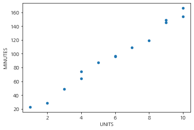

```python
df_raw.plot.scatter(x="UNITS", y="MINUTES")
```

```python
df_raw.corr(method = "pearson").round(3)
```

|  | UNITS | MINUTES |
| --- | --- | --- |
| UNITS | 1.000 | 0.994 |
| MINUTES | 0.994 | 1.000 |

-> 상관계수가 0.994로 매우 높은 선형관계가 있다.

```python
reg_model = smf.ols(formula = "MINUTES ~ UNITS", data = df_raw)  # OLS: 최소자승법
reg_result = reg_model.fit()
print(reg_result.summary())
```

```
                            OLS Regression Results
==============================================================================
Dep. Variable:                MINUTES   R-squared:                       0.987
Model:                            OLS   Adj. R-squared:                  0.986
Method:                 Least Squares   F-statistic:                     943.2
Date:                Mon, 23 May 2022   Prob (F-statistic):           8.92e-13
Time:                        15:10:06   Log-Likelihood:                -42.374
No. Observations:                  14   AIC:                             88.75
Df Residuals:                      12   BIC:                             90.03
Df Model:                           1
Covariance Type:            nonrobust
==============================================================================
                 coef    std err          t      P>|t|      [0.025      0.975]
------------------------------------------------------------------------------
Intercept      4.1617      3.355      1.240      0.239      -3.148      11.472
UNITS         15.5088      0.505     30.712      0.000      14.409      16.609
==============================================================================
Omnibus:                        0.746   Durbin-Watson:                   2.051
Prob(Omnibus):                  0.689   Jarque-Bera (JB):                0.624
Skew:                          -0.069   Prob(JB):                        0.732
Kurtosis:                       1.975   Cond. No.                         15.8
==============================================================================

Notes:
[1] Standard Errors assume that the covariance matrix of the errors is correctly specified.
```

- 분석 자료 수: 14
- 잔차 자유도: 12
- 모델 자유도: 1
- 계수: 15.5088
- y절편: 4.1617

H0: x가 y에 영향이 없다.  
H1: x가 y에 영향이 있다.

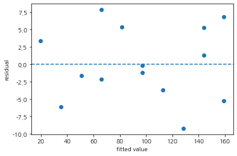

```python
plt.scatter(reg_result.fittedvalues, reg_result.resid)
plt.xlabel("fitted value")
plt.ylabel("residual")
plt.axhline(y = 0, linestyle = "--")
```

-> 잔차가 y=0을 기준으로 랜덤하게 산포되어 있으므로 등분산성 만족

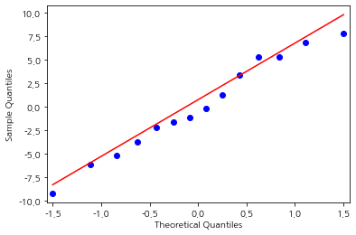

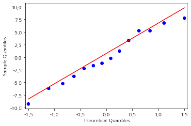

```python
qqplot(reg_result.resid, line = 'q')
```

-> 정규분포 직선을 중심으로 분포하므로 정규분포를 따른다.

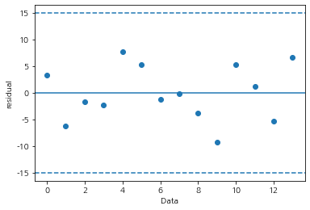

```python
plt.scatter(df_raw.index, reg_result.resid, marker="o")
plt.xlabel("Data")
plt.ylabel("residual")
plt.axhline(y = 0, linestyle = "-")
plt.axhline(y = 3*np.std(reg_result.resid), linestyle = "--")
plt.axhline(y = -3*np.std(reg_result.resid), linestyle = "--")
```

-> 잔차가 y=0을 기준으로 관리상하한을 벗어나지 않고 랜덤하게 산포되어 있으므로 독립성을 만족

#### 다중 선형회귀

- 설명변수 여러개, 목표변수와 선형관계를 가지는 회귀 모델
- 분석 절차
  1. 경향성 확인: 변수 간의 상관성 확인, 주요 변수 이해 및 선정
     - 상관분석
  2. 모델링: 회귀계수 계산, 회귀계수의 유의성 검정, 목표변수에 영향을 미치는 독립변수 확인, 독립변수 간의 다중 공선성
     - 회귀계수 산정: 최소자승법
     - 다중 공선성: 설명변수 간의 상관관계가 높아 발생, 분산팽창계수(VIF)가 10보다 크면 다중 공선성이 존재한다고 본다.
  3. 모델의 적합성 확인: 표준오차, 결정계수, ANOVA 분석결과 확인
  4. 오차(잔차)의 가정 확인: 오차의 정규성, 등분산성, 독립성 확인
     - 잔차 분석
  5. 모델 확정
     - 변수선택법: 전진선택법, 후진제거법, 단계적방법, 모든 가능한 회귀

```python
# 데이터 처리
import pandas as pd

# 행렬 연산
import numpy as np

# 데이터 시각화
import matplotlib
import matplotlib.pyplot as plt
import seaborn as sns

# 회귀분석
from statsmodels.formula.api import ols

# qqplot, 회귀분석의 상수항 추가
from statsmodels.api import qqplot, add_constant

# 선형 모델 formula(y ~ X1 + X2 + ...)
import statsmodels.formula.api as smf

# 다중공선성 확인
from statsmodels.stats.outliers_influence import variance_inflation_factor

# 학습용/평가용 데이터 분리: traing, test
from sklearn.model_selection import train_test_split

# 선형회귀모형
from sklearn.linear_model import LinearRegression

# 변수 선택법(후진제거법)
from sklearn.feature_selection import RFE

# Scale 변환-> 표준화 회귀계수 산출
from sklearn.preprocessing import StandardScaler

# 평가함수
from statsmodels.tools.eval_measures import rmse
from sklearn.metrics import r2_score
```

```python
df_raw = pd.read_csv("../빅데이터 기초/Data/체질검사.csv")
df_raw.head()
```

|  | FAT | AGE | WEIGHT | HEIGHT | NECK | CHEST | ABDOMEN | HIP | THIGH | KNEE | ANKLE | BICEPS | FOREARM | WRIST |
| --- | --- | --- | --- | --- | --- | --- | --- | --- | --- | --- | --- | --- | --- | --- |
| 0 | 35.2 | 46 | 363.15 | 72.25 | 51.2 | 136.2 | 148.1 | 147.7 | 87.3 | 49.1 | 29.6 | 45.0 | 29.0 | 21.4 |
| 1 | 11.8 | 27 | 168.00 | 71.25 | 38.1 | 93.0 | 79.1 | 94.5 | 57.3 | 36.2 | 24.5 | 29.0 | 30.0 | 18.8 |
| 2 | 22.2 | 69 | 177.75 | 68.50 | 38.7 | 102.0 | 95.0 | 98.3 | 55.0 | 38.3 | 21.8 | 30.8 | 25.7 | 18.8 |
| 3 | 10.6 | 57 | 147.75 | 65.75 | 35.2 | 99.6 | 86.4 | 90.1 | 53.0 | 35.0 | 21.3 | 31.7 | 27.3 | 16.9 |
| 4 | 47.5 | 51 | 219.00 | 64.00 | 41.2 | 119.8 | 122.1 | 112.8 | 62.5 | 36.9 | 23.6 | 34.7 | 29.1 | 18.4 |

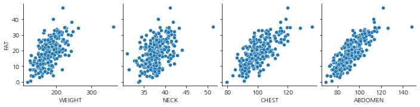

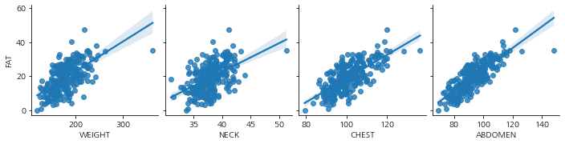

```python
sns.pairplot(df_raw, y_vars="FAT", x_vars=["WEIGHT", "NECK", "CHEST", "ABDOMEN"])
sns.pairplot(df_raw, y_vars="FAT", x_vars=["WEIGHT", "NECK", "CHEST", "ABDOMEN"], kind="reg")
```

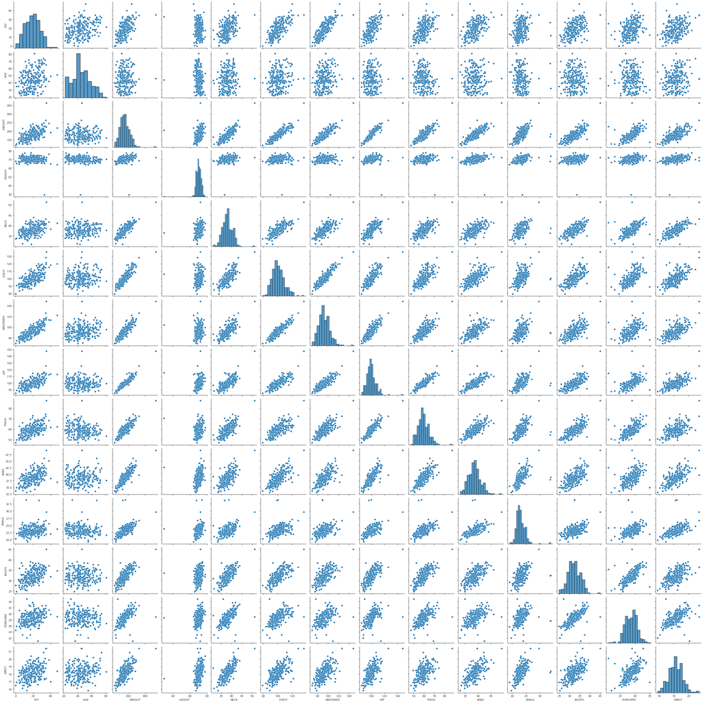

```python
sns.pairplot(df_raw)
```

```python
df_raw.corr().round(3)
```

|  | FAT | AGE | WEIGHT | HEIGHT | NECK | CHEST | ABDOMEN | HIP | THIGH | KNEE | ANKLE | BICEPS | FOREARM | WRIST |
| --- | --- | --- | --- | --- | --- | --- | --- | --- | --- | --- | --- | --- | --- | --- |
| FAT | 1.000 | 0.291 | 0.612 | -0.089 | 0.491 | 0.703 | 0.813 | 0.625 | 0.560 | 0.509 | 0.266 | 0.493 | 0.361 | 0.347 |
| AGE | 0.291 | 1.000 | -0.013 | -0.172 | 0.114 | 0.176 | 0.230 | -0.050 | -0.200 | 0.018 | -0.105 | -0.041 | -0.085 | 0.214 |
| WEIGHT | 0.612 | -0.013 | 1.000 | 0.308 | 0.831 | 0.894 | 0.888 | 0.941 | 0.869 | 0.853 | 0.614 | 0.800 | 0.630 | 0.730 |
| HEIGHT | -0.089 | -0.172 | 0.308 | 1.000 | 0.254 | 0.135 | 0.088 | 0.170 | 0.148 | 0.286 | 0.265 | 0.208 | 0.229 | 0.322 |
| NECK | 0.491 | 0.114 | 0.831 | 0.254 | 1.000 | 0.785 | 0.754 | 0.735 | 0.696 | 0.672 | 0.478 | 0.731 | 0.624 | 0.745 |
| CHEST | 0.703 | 0.176 | 0.894 | 0.135 | 0.785 | 1.000 | 0.916 | 0.829 | 0.730 | 0.719 | 0.483 | 0.728 | 0.580 | 0.660 |
| ABDOMEN | 0.813 | 0.230 | 0.888 | 0.088 | 0.754 | 0.916 | 1.000 | 0.874 | 0.767 | 0.737 | 0.453 | 0.685 | 0.503 | 0.620 |
| HIP | 0.625 | -0.050 | 0.941 | 0.170 | 0.735 | 0.829 | 0.874 | 1.000 | 0.896 | 0.823 | 0.558 | 0.739 | 0.545 | 0.630 |
| THIGH | 0.560 | -0.200 | 0.869 | 0.148 | 0.696 | 0.730 | 0.767 | 0.896 | 1.000 | 0.799 | 0.540 | 0.761 | 0.567 | 0.559 |
| KNEE | 0.509 | 0.018 | 0.853 | 0.286 | 0.672 | 0.719 | 0.737 | 0.823 | 0.799 | 1.000 | 0.612 | 0.679 | 0.556 | 0.665 |
| ANKLE | 0.266 | -0.105 | 0.614 | 0.265 | 0.478 | 0.483 | 0.453 | 0.558 | 0.540 | 0.612 | 1.000 | 0.485 | 0.419 | 0.566 |
| BICEPS | 0.493 | -0.041 | 0.800 | 0.208 | 0.731 | 0.728 | 0.685 | 0.739 | 0.761 | 0.679 | 0.485 | 1.000 | 0.678 | 0.632 |
| FOREARM | 0.361 | -0.085 | 0.630 | 0.229 | 0.624 | 0.580 | 0.503 | 0.545 | 0.567 | 0.556 | 0.419 | 0.678 | 1.000 | 0.586 |
| WRIST | 0.347 | 0.214 | 0.730 | 0.322 | 0.745 | 0.660 | 0.620 | 0.630 | 0.559 | 0.665 | 0.566 | 0.632 | 0.586 | 1.000 |

-> FAT와 CHEST, ABDOMEN 간의 높은 선형관계 확인

```python
df_train, df_test = train_test_split(df_raw, test_size=0.3, random_state=1234)
print("train data size: {}".format(df_train.shape))
print("test data size: {}".format(df_test.shape))
```

```
train data size: (176, 14)
test data size: (76, 14)
```

```python
reg_model = smf.ols(formula= "FAT ~ AGE + WEIGHT + HEIGHT + NECK + CHEST + ABDOMEN + HIP + THIGH +\
                            KNEE + ANKLE + BICEPS + FOREARM + WRIST", data=df_train)

reg_result = reg_model.fit()
print(reg_result.summary())
```

[output not shown]

```python
# p값이 0.05보다 큰 변수를 하나씩 반복적으로 제거한 결과

reg_model = smf.ols(formula= "FAT ~ WEIGHT + ABDOMEN + FOREARM + WRIST", data=df_train)

reg_result = reg_model.fit()
print(reg_result.summary())
```

```
                            OLS Regression Results
==============================================================================
Dep. Variable:                    FAT   R-squared:                       0.753
Model:                            OLS   Adj. R-squared:                  0.747
Method:                 Least Squares   F-statistic:                     130.5
Date:                Mon, 23 May 2022   Prob (F-statistic):           7.27e-51
Time:                        16:05:58   Log-Likelihood:                -500.95
No. Observations:                 176   AIC:                             1012.
Df Residuals:                     171   BIC:                             1028.
Df Model:                           4
Covariance Type:            nonrobust
==============================================================================
                 coef    std err          t      P>|t|      [0.025      0.975]
------------------------------------------------------------------------------
Intercept    -46.5507      8.472     -5.495      0.000     -63.274     -29.828
WEIGHT        -0.1617      0.028     -5.817      0.000      -0.217      -0.107
ABDOMEN        1.0089      0.062     16.240      0.000       0.886       1.132
FOREARM        0.6490      0.220      2.949      0.004       0.215       1.083
WRIST         -0.9575      0.493     -1.943      0.054      -1.930       0.015
==============================================================================
Omnibus:                        8.349   Durbin-Watson:                   2.068
Prob(Omnibus):                  0.015   Jarque-Bera (JB):                3.995
Skew:                           0.083   Prob(JB):                        0.136
Kurtosis:                       2.281   Cond. No.                     5.49e+03
==============================================================================

Notes:
[1] Standard Errors assume that the covariance matrix of the errors is correctly specified.
[2] The condition number is large, 5.49e+03. This might indicate that there are
strong multicollinearity or other numerical problems.
```

-> WRIST의 p값이 0.054이지만 모델에 포함시켰다.

```python
df_train_x = df_train[["WEIGHT", "ABDOMEN", "FOREARM", "WRIST"]]

df_train_x_const = add_constant(df_train_x)

df_vif = pd.DataFrame()
df_vif["variable"] = df_train_x_const.columns
df_vif["VIF"] = [variance_inflation_factor(df_train_x_const.values, i) for i in range(df_train_x_const.shape[1])]

df_vif.sort_values("VIF", inplace=True)
df_vif.round(3)
```

|  | variable | VIF |
| --- | --- | --- |
| 3 | FOREARM | 1.723 |
| 4 | WRIST | 2.231 |
| 2 | ABDOMEN | 4.642 |
| 1 | WEIGHT | 6.911 |
| 0 | const | 706.602 |

-> VIF가 10 이상인 변수가 없으므로 다중공선성이 없다.

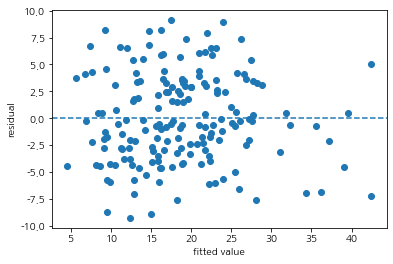

```python
plt.scatter(reg_result.fittedvalues, reg_result.resid)
plt.xlabel("fitted value")
plt.ylabel("residual")
plt.axhline(y = 0, linestyle = "--")
```

-> 잔차가 y=0을 기준으로 랜덤하게 산포되어 있으므로 등분산성 만족

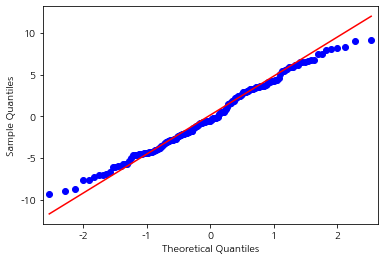

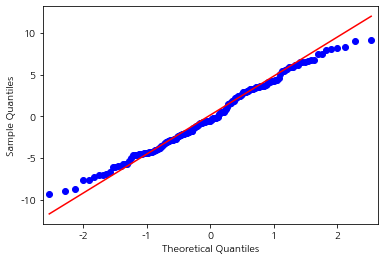

```python
qqplot(reg_result.resid, line = "q")
```

-> 정규분포 직선(적색 선)을 중심으로 분포하므로 정규분포를 따른다.

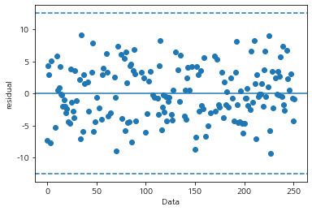

```python
plt.scatter(df_train.index, reg_result.resid, marker="o")
plt.xlabel("Data")
plt.ylabel("residual")
plt.axhline(y = 0, linestyle = "-")
plt.axhline(y = 3*np.std(reg_result.resid), linestyle="--")
plt.axhline(y = -3*np.std(reg_result.resid), linestyle="--")
```

-> 잔차가 y=0을 기준으로 관리상하한을 벗어나지 않고 랜덤하게 산포되어 있으므로 독립성을 만족

```python
train_pred = reg_result.predict(df_train)
test_pred = reg_result.predict(df_test)
print("train data의 결정계수:", r2_score(df_train['FAT'], train_pred))
print("test data의 결정계수:", r2_score(df_test['FAT'], test_pred))
```

```
train data의 결정계수: 0.7531979313129462
test data의 결정계수: 0.6710568091890075
```

```python
# 후진제거법을 이용한 변수 선택

df_train_y = df_train['FAT']
df_train_x = df_train.drop('FAT', axis=1)

model = LinearRegression()

rfe = RFE(estimator=model, n_features_to_select=4).fit(df_train_x, df_train_y)

selected_cols = df_train_x.columns[rfe.support_]

removed_cols = df_train_x.columns[~rfe.support_]

print("Selected Variables: {}".format(selected_cols))
print("Removed Variables: {}".format(removed_cols))
```

```
Selected Variables: Index(['NECK', 'ABDOMEN', 'FOREARM', 'WRIST'], dtype='object')
Removed Variables: Index(['AGE', 'WEIGHT', 'HEIGHT', 'CHEST', 'HIP', 'THIGH', 'KNEE', 'ANKLE',
       'BICEPS'],
      dtype='object')
```

```python
rfe_reg_model = smf.ols(formula="FAT ~ NECK + ABDOMEN + FOREARM + WRIST", data = df_train)

rfe_reg_result = rfe_reg_model.fit()
print(rfe_reg_result.summary())
```

```
                            OLS Regression Results
==============================================================================
Dep. Variable:                    FAT   R-squared:                       0.721
Model:                            OLS   Adj. R-squared:                  0.714
Method:                 Least Squares   F-statistic:                     110.3
Date:                Mon, 23 May 2022   Prob (F-statistic):           2.68e-46
Time:                        16:44:04   Log-Likelihood:                -511.82
No. Observations:                 176   AIC:                             1034.
Df Residuals:                     171   BIC:                             1049.
Df Model:                           4
Covariance Type:            nonrobust
==============================================================================
                 coef    std err          t      P>|t|      [0.025      0.975]
------------------------------------------------------------------------------
Intercept    -10.5046      6.969     -1.507      0.134     -24.261       3.252
NECK          -0.7758      0.245     -3.170      0.002      -1.259      -0.293
ABDOMEN        0.7919      0.046     17.385      0.000       0.702       0.882
FOREARM        0.3672      0.225      1.629      0.105      -0.078       0.812
WRIST         -1.3656      0.535     -2.553      0.012      -2.421      -0.310
==============================================================================
Omnibus:                        0.132   Durbin-Watson:                   1.950
Prob(Omnibus):                  0.936   Jarque-Bera (JB):                0.254
Skew:                           0.051   Prob(JB):                        0.881
Kurtosis:                       2.845   Cond. No.                     2.18e+03
==============================================================================

Notes:
[1] Standard Errors assume that the covariance matrix of the errors is correctly specified.
[2] The condition number is large, 2.18e+03. This might indicate that there are
strong multicollinearity or other numerical problems.
```

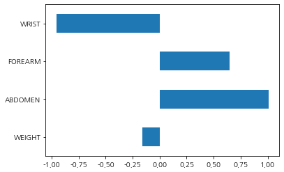

```python
selected_cols = ['WEIGHT', 'ABDOMEN', 'FOREARM', 'WRIST']
df_reg_coef = pd.DataFrame({"Coef": reg_result.params.values[1:]}, index = selected_cols)
df_reg_coef.plot.barh(y = "Coef", legend = False)
```

### 회귀분석

#### Ridge 회귀분석

```python
from sklearn.linear_model import Ridge, Lasso, ElasticNet
```

```python
df_raw_y = df_raw["FAT"]
df_raw_x = df_raw.drop("FAT", axis=1, inplace=False)

df_train_x, df_test_x, df_train_y, df_test_y = train_test_split(df_raw_x, df_raw_y, test_size=0.3, random_state=1234)

print("train data X size: {}".format(df_train_x.shape))
print("train data Y size: {}".format(df_train_y.shape))
print("test data X size: {}".format(df_test_x.shape))
print("test data Y size: {}".format(df_test_y.shape))
```

```
train data X size: (176, 13)
train data Y size: (176,)
test data X size: (76, 13)
test data Y size: (76,)
```

```
-36.01357891268792
```

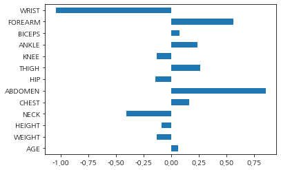

```python
ridge = Ridge(random_state=1234, alpha=1)
ridge.fit(df_train_x, df_train_y)

print(ridge.intercept_)

df_ridge_coef = pd.DataFrame({"Coef": ridge.coef_}, index = df_train_x.columns)

df_ridge_coef.plot.barh(y = "Coef", legend = False)
```

```python
train_pred = ridge.predict(df_train_x)
test_pred = ridge.predict(df_test_x)
print("train data의 결정계수:", r2_score(df_train_y, train_pred))
print("test data의 결정계수:", r2_score(df_test_y, test_pred))
```

```
train data의 결정계수: 0.7688327524317085
test data의 결정계수: 0.6641643344921555
```

#### LASSO 회귀분석

```
-39.35090439476542
```

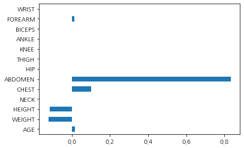

```python
lasso = Lasso(random_state=1234, alpha=1)
lasso.fit(df_train_x, df_train_y)

print(lasso.intercept_)

df_lasso_coef = pd.DataFrame({"Coef": lasso.coef_}, index=df_train_x.columns)

df_lasso_coef.plot.barh(y = "Coef", legend=False)
```

```python
train_pred = lasso.predict(df_train_x)
test_pred = lasso.predict(df_test_x)
print("train data의 결정계수:", r2_score(df_train_y, train_pred))
print("test data의 결정계수:", r2_score(df_test_y, test_pred))
```

```
train data의 결정계수: 0.7448823019911712
test data의 결정계수: 0.6397843604404867
```

#### Elastic Net 회귀분석

```
-47.00875497399707
```

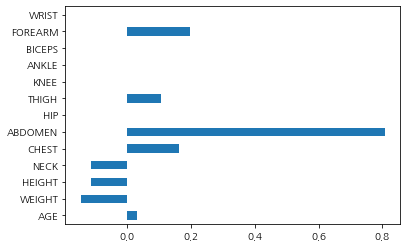

```python
elastic = ElasticNet(random_state=1234, alpha=1, l1_ratio=0.5)
elastic.fit(df_train_x, df_train_y)

print(elastic.intercept_)

df_elastic_coef = pd.DataFrame({"Coef": elastic.coef_}, index = df_train_x.columns)

df_elastic_coef.plot.barh(y = "Coef", legend = False)
```

```python
train_pred = elastic.predict(df_train_x)
test_pred = elastic.predict(df_test_x)
print("train data의 결정계수:", r2_score(df_train_y, train_pred))
print("test data의 결정계수:", r2_score(df_test_y, test_pred))
```

```
train data의 결정계수: 0.7549442655494084
test data의 결정계수: 0.636671178295827
```

#### 비선형회귀

- 2차, 지수 등 비선형 관계